# Project: Model Tuning - ReneWind

[figure not shown]

### Business Context

Renewable energy sources play an increasingly important role in the global energy mix, as the effort to reduce the environmental impact of energy production increases.

Out of all the renewable energy alternatives, wind energy is one of the most developed technologies worldwide. The U.S Department of Energy has put together a guide to achieving operational efficiency using predictive maintenance practices.

Predictive maintenance uses sensor information and analysis methods to measure and predict degradation and future component capability. The idea behind predictive maintenance is that failure patterns are predictable and if component failure can be predicted accurately and the component is replaced before it fails, the costs of operation and maintenance will be much lower.

The sensors fitted across different machines involved in the process of energy generation collect data related to various environmental factors (temperature, humidity, wind speed, etc.) and additional features related to various parts of the wind turbine (gearbox, tower, blades, break, etc.).

## Objective

“ReneWind” is a company working on improving the machinery/processes involved in the production of wind energy using machine learning and has collected data of generator failure of wind turbines using sensors. They have shared a ciphered version of the data, as the data collected through sensors is confidential (the type of data collected varies with companies). Data has 40 predictors, 20000 observations in the training set and 5000 in the test set.

The objective is to build various classification models, tune them, and find the best one that will help identify failures so that the generators could be repaired before failing/breaking to reduce the overall maintenance cost. The nature of predictions made by the classification model will translate as follows:

- True positives (TP) are failures correctly predicted by the model. These will result in repairing costs.
- False negatives (FN) are real failures where there is no detection by the model. These will result in replacement costs.
- False positives (FP) are detections where there is no failure. These will result in inspection costs.

It is given that the cost of repairing a generator is much less than the cost of replacing it, and the cost of inspection is less than the cost of repair.

“1” in the target variables should be considered as “failure” and “0” represents “No failure”.

## Data Description

- The data provided is a transformed version of original data which was collected using sensors.
- Train.csv - To be used for training and tuning of models.
- Test.csv - To be used only for testing the performance of the final best model.
- Both the datasets consist of 40 predictor variables and 1 target variable

## Index to Important Sections:

- Data Overview
- Exploratory Data Analysis (EDA)
- Data Preprocessing
- Model Building
- Hyperparameter Tuning
- Compare model performance & Final model selection
- Pipeline to build final model
- Business Insights and Conclusion

## Importing necessary libraries

```python
# Ignore warnings
import warnings
warnings.filterwarnings('ignore')

# Data manipulation and analysis
import pandas as pd
import numpy as np
from math import ceil

# Data visualization
import matplotlib.pyplot as plt
import seaborn as sns

# Preprocessing
from sklearn.model_selection import train_test_split #Spliting data
from sklearn.model_selection import StratifiedKFold, cross_val_score #K-Fold and Cross Validation scores
from sklearn.impute import KNNImputer #Treat missing values
from imblearn.over_sampling import SMOTE #Synthetic Data Creation in Minority Class using Oversampling
from imblearn.under_sampling import RandomUnderSampler #Data Removl from Majority Class using Undersampling

# Machine Learning Models
from sklearn.linear_model import LogisticRegression
from sklearn.tree import DecisionTreeClassifier
from sklearn.ensemble import RandomForestClassifier, BaggingClassifier, GradientBoostingClassifier
from xgboost import XGBClassifier

# Model Evaluation
from sklearn.metrics import classification_report, confusion_matrix, accuracy_score, recall_score, precision_score, f1_score
from sklearn import metrics

# Hyperparameter Tuning
from sklearn.model_selection import RandomizedSearchCV

# Pipeline - using imblearn over sklearn for its compatibility to include sampling techniques
from imblearn.pipeline import Pipeline

# Set pandas display options for better readability of output
pd.set_option("display.max_columns", None)
pd.set_option("display.max_rows", 200)
pd.set_option("display.float_format", lambda x: "%.5f" % x)

# Set Seaborn aesthetic parameters
sns.set(
    context='notebook',
    style='darkgrid',
    #palette="Blues",
    font='sans-serif',
    font_scale=0.8,
    rc={'figure.figsize': (8, 5)}
)
```

**Note:** After running the above cell, kindly restart the notebook kernel and run all cells sequentially from the start again.

## Loading the dataset

```python
# Connect to Google Drive
from google.colab import drive
drive.mount('/content/drive')
```

```python
# Load Data
testdata = pd.read_csv('/content/drive/MyDrive/Colab Notebooks/Model Tuning/Project/Test.csv')
traindata = pd.read_csv('/content/drive/MyDrive/Colab Notebooks/Model Tuning/Project/Train.csv')
```

## Data Overview

- View Data (top and bottom rows)
- Shape of the dataset
- Dataset information
- Dateset Statistics

### View Data (Top and bottom rows)

```python
# Display Top 5 Rows of Data in Train Dataset
traindata.head()
```

|  | V1 | V2 | V3 | V4 | V5 | V6 | V7 | V8 | V9 | V10 | V11 | V12 | V13 | V14 | V15 | V16 | V17 | V18 | V19 | V20 | V21 | V22 | V23 | V24 | V25 | V26 | V27 | V28 | V29 | … |
| --- | --- | --- | --- | --- | --- | --- | --- | --- | --- | --- | --- | --- | --- | --- | --- | --- | --- | --- | --- | --- | --- | --- | --- | --- | --- | --- | --- | --- | --- | --- |
| 0 | -4.46461 | -4.67913 | 3.10155 | 0.50613 | -0.22108 | -2.03251 | -2.91087 | 0.05071 | -1.52235 | 3.76189 | -5.71472 | 0.73589 | 0.98125 | 1.41788 | -3.37582 | -3.04730 | 0.30619 | 2.91410 | 2.26998 | 4.39488 | -2.38830 | 0.64639 | -1.19051 | 3.13299 | 0.66528 | -2.51085 | -0.03674 | 0.72622 | -3.98219 | … |
| 1 | 3.36591 | 3.65338 | 0.90967 | -1.36753 | 0.33202 | 2.35894 | 0.73260 | -4.33213 | 0.56569 | -0.10108 | 1.91446 | -0.95146 | -1.25526 | -2.70652 | 0.19322 | -4.76938 | -2.20532 | 0.90772 | 0.75689 | -5.83368 | -3.06512 | 1.59665 | -1.75731 | 1.76644 | -0.26710 | 3.62504 | 1.50035 | -0.58571 | 0.78303 | … |
| 2 | -3.83184 | -5.82444 | 0.63403 | -2.41882 | -1.77383 | 1.01682 | -2.09894 | -3.17320 | -2.08186 | 5.39262 | -0.77067 | 1.10672 | 1.14426 | 0.94330 | -3.16380 | -4.24782 | -4.03891 | 3.68853 | 3.31120 | 1.05900 | -2.14303 | 1.65012 | -1.66059 | 1.67991 | -0.45078 | -4.55069 | 3.73878 | 1.13440 | -2.03353 | … |
| 3 | 1.61810 | 1.88834 | 7.04614 | -1.14728 | 0.08308 | -1.52978 | 0.20731 | -2.49363 | 0.34493 | 2.11858 | -3.05302 | 0.45972 | 2.70453 | -0.63609 | -0.45372 | -3.17405 | -3.40435 | -1.28154 | 1.58210 | -1.95178 | -3.51656 | -1.20601 | -5.62785 | -1.81765 | 2.12414 | 5.29464 | 4.74814 | -2.30854 | -3.96298 | … |
| 4 | -0.11144 | 3.87249 | -3.75836 | -2.98290 | 3.79271 | 0.54496 | 0.20543 | 4.84899 | -1.85492 | -6.22002 | 1.99835 | 4.72376 | 0.70911 | -1.98943 | -2.63268 | 4.18445 | 2.24536 | 3.73445 | -6.31277 | -5.37992 | -0.88667 | 2.06169 | 9.44559 | 4.48998 | -3.94514 | 4.58207 | -8.78042 | -3.38297 | 5.10651 | … |

```python
# Display Bottom 5 Rows of Data in Train Dataset
traindata.tail()
```

|  | V1 | V2 | V3 | V4 | V5 | V6 | V7 | V8 | V9 | V10 | V11 | V12 | V13 | V14 | V15 | V16 | V17 | V18 | V19 | V20 | V21 | V22 | V23 | V24 | V25 | V26 | V27 | V28 | V29 | … |
| --- | --- | --- | --- | --- | --- | --- | --- | --- | --- | --- | --- | --- | --- | --- | --- | --- | --- | --- | --- | --- | --- | --- | --- | --- | --- | --- | --- | --- | --- | --- |
| 19995 | -2.07132 | -1.08828 | -0.79617 | -3.01172 | -2.28754 | 2.80731 | 0.48143 | 0.10517 | -0.58660 | -2.89940 | 8.86842 | 1.71716 | 1.35784 | -1.77713 | 0.70978 | 4.94494 | -3.10045 | -1.19923 | -1.08463 | -0.36504 | 3.13117 | -3.94810 | -3.57847 | -8.13907 | -1.93686 | -1.32769 | -0.40269 | -1.73480 | 9.99646 | … |
| 19996 | 2.89026 | 2.48307 | 5.64392 | 0.93705 | -1.38087 | 0.41205 | -1.59339 | -5.76250 | 2.15010 | 0.27230 | -2.09476 | -1.52583 | 0.07157 | -3.54014 | -2.76201 | -10.63221 | -0.49524 | 1.72007 | 3.87160 | -1.20961 | -8.22207 | 2.12087 | -5.49181 | 1.45234 | 1.45000 | 3.68465 | 1.07676 | -0.38417 | -0.83859 | … |
| 19997 | -3.89698 | -3.94241 | -0.35136 | -2.41746 | 1.10755 | -1.52762 | -3.51988 | 2.05479 | -0.23400 | -0.35769 | -3.78197 | 2.18004 | 6.11178 | 1.98475 | -8.33000 | -1.63918 | -0.91496 | 5.67235 | -3.92420 | 2.13320 | -4.50203 | 2.77718 | 5.72795 | 1.61982 | -1.69969 | -0.04188 | -2.92309 | -2.76016 | -2.25377 | … |
| 19998 | -3.18732 | -10.05166 | 5.69596 | -4.37005 | -5.35476 | -1.87304 | -3.94721 | 0.67942 | -2.38925 | 5.45676 | 1.58303 | 3.57148 | 9.22657 | 2.55359 | -7.03911 | -0.99357 | -9.66494 | 1.15522 | 3.87689 | 3.52363 | -7.01533 | -0.13204 | -3.44618 | -4.80144 | -0.87573 | -3.81185 | 5.42208 | -3.73232 | 0.60881 | … |
| 19999 | -2.68690 | 1.96119 | 6.13709 | 2.60013 | 2.65724 | -4.29088 | -2.34427 | 0.97400 | -1.02746 | 0.49742 | -9.58907 | 3.17656 | 1.05452 | -1.41588 | -4.66861 | -5.40538 | 3.71976 | 2.89292 | 2.32859 | 1.45770 | -6.42854 | 1.81823 | 0.80590 | 7.78603 | 0.33086 | 5.25742 | -4.86742 | -0.81894 | -5.66739 | … |

### Shape of the Data

- Train.csv dataset has 20,000 observations with 41 columns.
- Test.csv dataset has 5,000 observations with 41 columns.

```python
# Shape of Train Dataset
print(f'Shape of Train Dataset: {traindata.shape}')
```

```
Shape of Train Dataset: (20000, 41)
```

```python
# Shape of Test Dataset
print(f'Shape of Test Dataset: {testdata.shape}')
```

```
Shape of Test Dataset: (5000, 41)
```

### Dataset Information

- All features are of numerical datatype in both, Train and Test datasets, there is no categorical data.
- There are 40 predictors (V1 to V40) with float64 datatype and a Target column (Target) of int64 datatype.
- There are missing values in V1 and V2 predictors in both datasets.
- Total memory usage for Train dataset is 6.3 MB.
- Total memory usage for Test dataset is 1.6 MB.

```python
# Train dataset information
traindata.info()
```

```
<class 'pandas.core.frame.DataFrame'>
RangeIndex: 20000 entries, 0 to 19999
Data columns (total 41 columns):
 #   Column  Non-Null Count  Dtype
---  ------  --------------  -----
 0   V1      19982 non-null  float64
 1   V2      19982 non-null  float64
 2   V3      20000 non-null  float64
 3   V4      20000 non-null  float64
 4   V5      20000 non-null  float64
 5   V6      20000 non-null  float64
 6   V7      20000 non-null  float64
 7   V8      20000 non-null  float64
 8   V9      20000 non-null  float64
 9   V10     20000 non-null  float64
```

[output cut: 33 more lines]

```python
# Test Dataset Information
testdata.info()
```

```
<class 'pandas.core.frame.DataFrame'>
RangeIndex: 5000 entries, 0 to 4999
Data columns (total 41 columns):
 #   Column  Non-Null Count  Dtype
---  ------  --------------  -----
 0   V1      4995 non-null   float64
 1   V2      4994 non-null   float64
 2   V3      5000 non-null   float64
 3   V4      5000 non-null   float64
 4   V5      5000 non-null   float64
 5   V6      5000 non-null   float64
 6   V7      5000 non-null   float64
 7   V8      5000 non-null   float64
 8   V9      5000 non-null   float64
 9   V10     5000 non-null   float64
```

[output cut: 33 more lines]

### Dataset Statistics

- Each feature has close to 20,000 observations, with slight missing values in some.
- The mean values across the features vary widely, from -3.61 to 2.48, suggesting different scales of measurement. The standard deviation also varies, from 1.65 to 5.50, indicating differing degrees of spread in the data.
- The range of values (min to max) is quite broad for several features, hinting at the presence of outliers or extreme values. It might be beneficial to investigate and potentially mitigate these outliers.
- The quartile distribution suggests that the features are mostly normally distributed.
- With missing values present, imputation or removal of these instances might be necessary.

```python
# Data Description for Train Dataset
traindata.describe().T
```

|  | count | mean | std | min | 25% | 50% | 75% | max |
| --- | --- | --- | --- | --- | --- | --- | --- | --- |
| V1 | 19982.00000 | -0.27200 | 3.44162 | -11.87645 | -2.73715 | -0.74792 | 1.84011 | 15.49300 |
| V2 | 19982.00000 | 0.44043 | 3.15078 | -12.31995 | -1.64067 | 0.47154 | 2.54397 | 13.08927 |
| V3 | 20000.00000 | 2.48470 | 3.38896 | -10.70814 | 0.20686 | 2.25579 | 4.56616 | 17.09092 |
| V4 | 20000.00000 | -0.08315 | 3.43160 | -15.08205 | -2.34766 | -0.13524 | 2.13061 | 13.23638 |
| V5 | 20000.00000 | -0.05375 | 2.10480 | -8.60336 | -1.53561 | -0.10195 | 1.34048 | 8.13380 |
| V6 | 20000.00000 | -0.99544 | 2.04097 | -10.22715 | -2.34724 | -1.00051 | 0.38033 | 6.97585 |
| V7 | 20000.00000 | -0.87932 | 1.76163 | -7.94968 | -2.03093 | -0.91718 | 0.22369 | 8.00609 |
| V8 | 20000.00000 | -0.54820 | 3.29576 | -15.65756 | -2.64266 | -0.38908 | 1.72297 | 11.67950 |
| V9 | 20000.00000 | -0.01681 | 2.16057 | -8.59631 | -1.49497 | -0.06760 | 1.40920 | 8.13758 |
| V10 | 20000.00000 | -0.01300 | 2.19320 | -9.85396 | -1.41121 | 0.10097 | 1.47705 | 8.10847 |
| V11 | 20000.00000 | -1.89539 | 3.12432 | -14.83206 | -3.92240 | -1.92124 | 0.11891 | 11.82643 |
| V12 | 20000.00000 | 1.60483 | 2.93045 | -12.94801 | -0.39651 | 1.50784 | 3.57145 | 15.08070 |
| V13 | 20000.00000 | 1.58049 | 2.87466 | -13.22825 | -0.22355 | 1.63719 | 3.45989 | 15.41962 |
| V14 | 20000.00000 | -0.95063 | 1.78965 | -7.73859 | -2.17074 | -0.95716 | 0.27068 | 5.67066 |
| V15 | 20000.00000 | -2.41499 | 3.35497 | -16.41661 | -4.41532 | -2.38262 | -0.35905 | 12.24645 |
| V16 | 20000.00000 | -2.92522 | 4.22172 | -20.37416 | -5.63424 | -2.68271 | -0.09505 | 13.58321 |
| V17 | 20000.00000 | -0.13426 | 3.34546 | -14.09118 | -2.21561 | -0.01458 | 2.06875 | 16.75643 |
| V18 | 20000.00000 | 1.18935 | 2.59228 | -11.64399 | -0.40392 | 0.88340 | 2.57177 | 13.17986 |
| V19 | 20000.00000 | 1.18181 | 3.39693 | -13.49178 | -1.05017 | 1.27906 | 3.49330 | 13.23774 |
| V20 | 20000.00000 | 0.02361 | 3.66948 | -13.92266 | -2.43295 | 0.03342 | 2.51237 | 16.05234 |
| V21 | 20000.00000 | -3.61125 | 3.56769 | -17.95623 | -5.93036 | -3.53289 | -1.26588 | 13.84047 |
| V22 | 20000.00000 | 0.95184 | 1.65155 | -10.12209 | -0.11813 | 0.97469 | 2.02559 | 7.40986 |
| V23 | 20000.00000 | -0.36612 | 4.03186 | -14.86613 | -3.09876 | -0.26209 | 2.45175 | 14.45873 |
| V24 | 20000.00000 | 1.13439 | 3.91207 | -16.38715 | -1.46806 | 0.96905 | 3.54598 | 17.16329 |
| V25 | 20000.00000 | -0.00219 | 2.01674 | -8.22827 | -1.36518 | 0.02505 | 1.39711 | 8.22339 |
| V26 | 20000.00000 | 1.87379 | 3.43514 | -11.83427 | -0.33786 | 1.95053 | 4.13004 | 16.83641 |
| V27 | 20000.00000 | -0.61241 | 4.36885 | -14.90494 | -3.65232 | -0.88489 | 2.18918 | 17.56040 |
| V28 | 20000.00000 | -0.88322 | 1.91771 | -9.26949 | -2.17122 | -0.89107 | 0.37588 | 6.52764 |
| V29 | 20000.00000 | -0.98563 | 2.68436 | -12.57947 | -2.78744 | -1.17618 | 0.62977 | 10.72206 |
| V30 | 20000.00000 | -0.01553 | 3.00526 | -14.79605 | -1.86711 | 0.18435 | 2.03623 | 12.50581 |
| V31 | 20000.00000 | 0.48684 | 3.46138 | -13.72276 | -1.81777 | 0.49030 | 2.73069 | 17.25509 |
| V32 | 20000.00000 | 0.30380 | 5.50040 | -19.87650 | -3.42047 | 0.05207 | 3.76172 | 23.63319 |
| V33 | 20000.00000 | 0.04983 | 3.57528 | -16.89835 | -2.24286 | -0.06625 | 2.25513 | 16.69249 |
| V34 | 20000.00000 | -0.46270 | 3.18384 | -17.98509 | -2.13698 | -0.25501 | 1.43693 | 14.35821 |
| V35 | 20000.00000 | 2.22962 | 2.93710 | -15.34980 | 0.33619 | 2.09863 | 4.06436 | 15.29106 |
| V36 | 20000.00000 | 1.51481 | 3.80086 | -14.83318 | -0.94381 | 1.56653 | 3.98394 | 19.32958 |
| V37 | 20000.00000 | 0.01132 | 1.78816 | -5.47835 | -1.25582 | -0.12843 | 1.17553 | 7.46701 |
| V38 | 20000.00000 | -0.34403 | 3.94815 | -17.37500 | -2.98764 | -0.31685 | 2.27940 | 15.28992 |
| V39 | 20000.00000 | 0.89065 | 1.75305 | -6.43888 | -0.27225 | 0.91926 | 2.05754 | 7.75988 |
| V40 | 20000.00000 | -0.87563 | 3.01215 | -11.02394 | -2.94019 | -0.92081 | 1.11990 | 10.65427 |
| Target | 20000.00000 | 0.05550 | 0.22896 | 0.00000 | 0.00000 | 0.00000 | 0.00000 | 1.00000 |

## Exploratory Data Analysis (EDA)

- Functions to assist in EDA
- Data Sanity Checks
- Univariate Analysis
- Bivariate Analysis

### Function to assist in EDA

- **histogram_boxplot_grid():** Displays a boxplot and a histogram along the same scale.
- **missing_values_table():** Displays Missing Values
- **significant_correlations():** Displays a heatmap of significant correlation between features.
- **print_significant_correlations():** Prints a table for each variable with significantly high correlation with other variables.
- **plot_bivariate_analysis_tv():** Plots bivariate analysis charts to show relationship between features and target variable.

```python
# Displays a boxplot and a histogram along the same scale.
def histogram_boxplot_grid(data):
    """
    Grid of boxplots and histograms for each feature in the dataset.
    data: training dataset
    """

    features = data.columns[:-1]  # Exclude the target column

    ncols = 4
    nrows = len(features) // ncols + (len(features) % ncols > 0)  # Calculate number of rows needed

    fig, axes = plt.subplots(nrows=nrows * 2, ncols=ncols, figsize=(20, 5 * nrows), gridspec_kw={'height_ratios': [1, 3] * nrows})

    for i, feature in enumerate(features):
        row, col = divmod(i, ncols)
        ax_box = axes[row * 2, col]
        ax_hist = axes[row * 2 + 1, col]

        # Plot the boxplot and histogram
        sns.boxplot(data=data, x=feature, ax=ax_box, showmeans=True, palette="coolwarm")
        sns.histplot(data=data, x=feature, kde=False, ax=ax_hist, palette="winter")

        # Add mean and median lines to the histogram
        ax_hist.axvline(data[feature].mean(), color="green", linestyle="--")
        ax_hist.axvline(data[feature].median(), color="black", linestyle="-")

        # Hide the x-axis labels for the boxplot
        ax_box.set_xlabel('')
        ax_box.set_xticks([])

    # Adjust the layout and remove empty subplots
    plt.tight_layout()
    for ax in axes.flat:
        if not ax.get_children():  # Check if the subplot is empty
            fig.delaxes(ax)  # Remove the empty subplot

# Displays Missing Values as a Dataframe
def missing_values_table(dataframe):
    """
    Display features with missing values, their count, and percentage of missing values.

    dataframe: pandas DataFrame
    """
    # Calculate the missing values for each feature
    missing_values = dataframe.isnull().sum()

    # Filter out features with no missing values
    missing_values = missing_values[missing_values > 0]

    # Calculate the percentage of missing values
    missing_percentage = (missing_values / len(dataframe)) * 100

    # Create a table with the results
    missing_table = pd.DataFrame({
        'Feature Name': missing_values.index,
        'Missing Value Count': missing_values.values,
        'Missing Value Percentage': missing_percentage.values
    })

    # Sort the table by the percentage of missing values in descending order
    missing_table = missing_table.sort_values(by='Missing Value Percentage', ascending=False).reset_index(drop=True)

    # Display the table
    if not missing_table.empty:
        return missing_table
    else:
        return "No missing values found in the dataset."

# Displays a heatmap of significant correlation between features.
def significant_correlations(dataframe, annot=True, threshold=0.5):
    """
    dataframe: pandas DataFrame
    annot: display correlation value True or False
    threshold: minimum absolute value of correlation coefficient to be considered significant (default 0.5)
    """
    # Exclude the target variable
    features = dataframe.drop(columns=['Target'])

    # Calculate the correlation matrix
    corr_matrix = features.corr()

    # Filter out correlations below the threshold and the diagonal (self-correlations)
    significant_corr = corr_matrix[abs(corr_matrix) >= threshold]
    significant_corr = significant_corr[significant_corr != 1]

    # Plot the heatmap
    plt.figure(figsize=(20, 12))
    sns.heatmap(significant_corr, annot=annot, cmap='coolwarm', fmt='.2f', vmin=-1, vmax=1)
    plt.title('Significant Correlations between Features')
    plt.show()

# Prints a table for each variable with significantly high correlation with other variables.
def print_significant_correlations(dataframe, threshold=0.5):
    """
    dataframe: pandas DataFrame
    threshold: minimum absolute value of correlation coefficient to be considered significant (default 0.5)
    """
    # Exclude the target variable
    features = dataframe.drop(columns=['Target'])

    # Calculate the correlation matrix
    corr_matrix = features.corr()

    # Iterate through each variable and print the significant correlations
    for variable in corr_matrix.columns:
        significant_corrs = corr_matrix[(abs(corr_matrix[variable]) >= threshold) & (corr_matrix[variable] != 1)][variable]
        if not significant_corrs.empty:
            print(f"Variable '{variable}' has significant correlations with:")
            print(significant_corrs.to_string(), '\n')

# Plots bivariate analysis charts depicting relationship between features and target variable.
def plot_bivariate_analysis_tv(df, target_variable, figsize_per_chart=(5, 4)):
    """
    Parameters:
    - df: pandas DataFrame
    - target_variable: str, the name of the target variable column in the DataFrame
    - figsize_per_chart: tuple, optional, the size of each subplot
    """
    # Create feature list
    features = df.columns.tolist()
    features.remove(target_variable) # Exclude the target variable

    # Total number of features
    total_features = len(features)

    # Calculate total rows needed for subplots (4 charts per row)
    total_rows = ceil(total_features / 4)

    # Create a figure for subplots
    fig, axes = plt.subplots(total_rows, 4, figsize=(figsize_per_chart[0]*4, figsize_per_chart[1]*total_rows))
    axes = axes.flatten()  # Flatten to 1D for easy indexing

    # Plot for numerical features
    for i, feature in enumerate(features):
        sns.boxplot(x=target_variable, y=feature, data=df, ax=axes[i], palette="coolwarm")
        axes[i].set_title(f'{feature} vs {target_variable}', fontsize=12)
        axes[i].set_xlabel(target_variable, fontsize=10)
        axes[i].set_ylabel(feature, fontsize=10)
        axes[i].tick_params(axis='x', rotation=45, labelsize=8)
        axes[i].tick_params(axis='y', labelsize=8)

    # Offset for categorical features in the subplot grid
    offset = len(features)

    # Hide any unused axes
    for ax in axes[total_features:]:
        ax.axis('off')

    # Adjust layout
    plt.tight_layout()
    plt.show()
```

### Data Sanity Checks

- There are missing values in features V1 and V2. We will treat them during Data Preprocessing.

```python
# Check for missing values
missing_values_table(traindata)
```

|  | Feature Name | Missing Value Count | Missing Value Percentage |
| --- | --- | --- | --- |
| 0 | V1 | 18 | 0.09000 |
| 1 | V2 | 18 | 0.09000 |

### Univariate Analysis

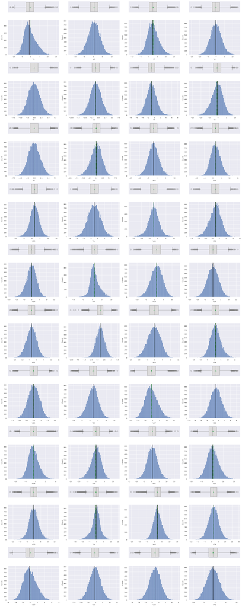

```python
# Display Boxplot and Histogram to analyze features
histogram_boxplot_grid(traindata)
```

**Observations:**

- **Normally Distributed:** All features show normal distribution.
- **Outliers:** There are outliers in almost all features.

### Bivariate Analysis:

1. Correlation Chart for Features
2. Relation with Target Variable

#### Correlation Chart for Features:

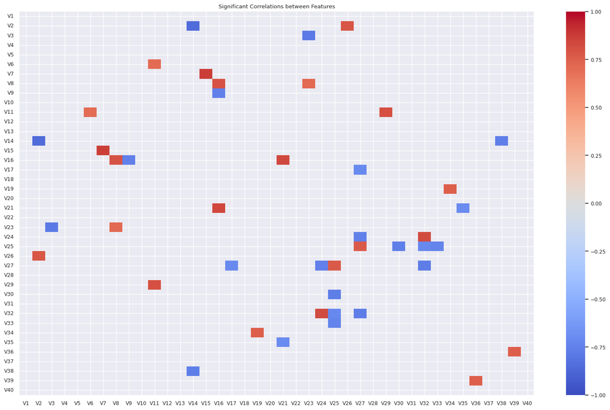

```python
# Display Heatmap to highlight correlation between features
significant_correlations(traindata,annot=False,threshold=0.7)
```

```python
# Print correlation values for highly correalted features for easy reference
print_significant_correlations(traindata,threshold=0.7)
```

```
Variable 'V2' has significant correlations with:
V14   -0.85353
V26    0.78744

Variable 'V3' has significant correlations with:
V23   -0.78558

Variable 'V6' has significant correlations with:
V11   0.71048

Variable 'V7' has significant correlations with:
V15   0.86787

Variable 'V8' has significant correlations with:
V16   0.80251
V23   0.71786

Variable 'V9' has significant correlations with:
V16   -0.75293

Variable 'V11' has significant correlations with:
V6    0.71048
V29   0.81123

Variable 'V14' has significant correlations with:
V2    -0.85353
V38   -0.76268

Variable 'V15' has significant correlations with:
V7   0.86787

Variable 'V16' has significant correlations with:
V8     0.80251
V9    -0.75293
V21    0.83653

Variable 'V17' has significant correlations with:
V27   -0.70660

Variable 'V19' has significant correlations with:
```

[output cut: 42 more lines]

```

Variable 'V34' has significant correlations with:
V19   0.75619

Variable 'V35' has significant correlations with:
V21   -0.70040

Variable 'V36' has significant correlations with:
V39   0.75173

Variable 'V38' has significant correlations with:
V14   -0.76268

Variable 'V39' has significant correlations with:
V36   0.75173
```

**Observations:**

Based on the provided correlation information between features where the correlation is 0.7 or more, here are some observations for Exploratory Data Analysis (EDA):

- **Strong Negative Correlations:** Several pairs of features exhibit strong negative correlations, such as V2 and V14 with a correlation coefficient of -0.85353. This suggests that as the value of one feature increases, the value of the other decreases. Identifying such relationships is crucial for understanding the inverse dependencies between features.
- **Strong Positive Correlations:** There are numerous instances of strong positive correlations, indicating that certain features move in the same direction. For example, V7 and V15 have a correlation of 0.86787, suggesting a strong direct relationship. Features with high positive correlations might convey redundant information.
- **Network of Correlated Features:** Some features are correlated with multiple other features, forming a network of correlations. For example, V25 shows significant correlations with V27, V30, V32, and V33. This suggests that V25 might be a central feature in its domain, influencing or being influenced by various other features.
- **Potential for Dimensionality Reduction:** The presence of strong correlations, both positive and negative, indicates opportunities for dimensionality reduction.
- **Implications for Model Training:** High correlations between features can impact machine learning models. For linear models, multicollinearity can inflate the variance of the coefficient estimates, making them unstable. For tree-based models, highly correlated features can lead to preference for one feature over another, potentially affecting the model's performance.
- **Diverse Relationships:** The varied nature of the correlations—spanning from very strong to moderate—across different feature pairs highlights the complex relationships in the dataset. It underscores the importance of a nuanced approach to feature selection and model building, considering both the strength and direction of these correlations.

Overall, the significant correlations between features underscore the need for careful data preprocessing, feature selection, and possibly dimensionality reduction to build effective and interpretable models.

#### Relation between Features and Target variable

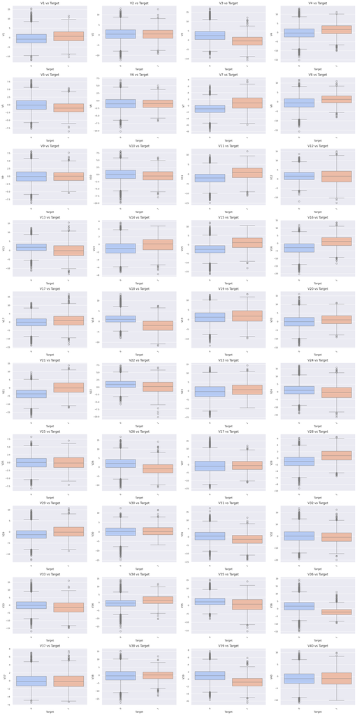

```python
# Plot correlation charts to compare significant features with target variable
plot_bivariate_analysis_tv(traindata, 'Target')
```

**Observations:**

- **Significantly Elevated for Failures (Target = 1):** Features V7, V11, V15, V16, V21, V28, and V34 show quartile values that are significantly higher for failures compared to no failures. This indicates these features may be strongly indicative of failure.
- **Moderately Elevated for Failures:** Features V1, V4, V8, V14, V17, V19, V20, V23, and V29 have quartile values that are moderately higher for failures. These features are also potentially relevant to predicting failure but with a more moderate influence.
- **Significantly Lower for Failures:** Features V3, V18, V26, and V36 show significantly lower quartile values for failures, suggesting a notable difference in these features when a failure occurs.
- **Moderately Lower for Failures:** Features V5, V9, V10, V13, V22, V24, V31, V32, V33, and V35 display moderately lower quartile values for failures. These may have some predictive value for the absence of failure.
- **Identical or Inconclusive:** Features V2, V6, V25, V27, V30, V37, V38, and V40 exhibit boxplot distributions that are more or less identical for both outcomes, suggesting no significant distinction in their quartile values between failures and no failures.
- **Mixed or Spread Out:** Feature V12's median remains unchanged across both classes, but the distribution for failures is more spread out, indicating higher variability for this feature when a failure occurs.
- **Outliers:** Features with No failures show significant outliers.

## Data Pre-processing

- Data Preparation
- Splitting Data
- Missing value treatment
- Checking for Collinearity

### Data Preparations:

#### Create Data Copies

```python
# Creating a copy of train dataset for preprocessing
traindata_dpp = traindata.copy()

# Creating a copy of test dataset for preprocessing
testdata_dpp = testdata.copy()
```

#### Check for Duplicates

```python
# Check for Duplicates
traindata_dpp.duplicated().sum()
```

```
0
```

- No duplicate records found

### Split Data

#### Split Training Set

```python
# Split dataset to separate features and target variable
X = traindata_dpp.drop(['Target'],axis=1)
y = traindata_dpp['Target']

# Print shape of Features and Target dataset
print(f'Features dataset shape: {X.shape}')
print(f'Target dataset shape: {y.shape}')
```

```
Features dataset shape: (20000, 40)
Target dataset shape: (20000,)
```

#### Split Test Set

```python
# Separate features and target for Test dataset
X_test = testdata_dpp.drop(['Target'],axis=1)
y_test = testdata_dpp['Target']
```

#### Create Training and Validation sets

```python
# Split data into train and validation sets
X_train, X_val, y_train, y_val = train_test_split(X,y,test_size=0.25,random_state=1,stratify=y)

# Display observations in Train, Validation and Test sets
print(f'Total observations in Train dataset: {X_train.shape[0]}')
print(f'Total observations in Validation dataset: {X_val.shape[0]}')
print(f'Total observations in Test dataset: {X_test.shape[0]}')
```

```
Total observations in Train dataset: 15000
Total observations in Validation dataset: 5000
Total observations in Test dataset: 5000
```

#### Display Class Disrtibution on Training, Validation and Test sets

```python
# Display target class distribution in Train, Validation and Test Datasets
print('\nPercentage of classes in training set:')
print(y_train.value_counts(normalize=True)*100)
print('\nPercentage of classes in validation set:')
print(y_val.value_counts(normalize=True)*100)
print('\nPercentage of classes in test set:')
print(y_test.value_counts(normalize=True)*100)
```

```
Percentage of classes in training set:
Target
0   94.45333
1    5.54667
Name: proportion, dtype: float64

Percentage of classes in validation set:
Target
0   94.44000
1    5.56000
Name: proportion, dtype: float64

Percentage of classes in test set:
Target
0   94.36000
1    5.64000
Name: proportion, dtype: float64
```

**Observations:**

- Train, Validation and Test datasets have 15,000, 5,000 and 5,000 observations respectively.
- Target variable is split as No Failure (0) 94.4% and Failure (1) 5.6%. Which highlights class imbalance.

### Missing value imputation

```python
# Display missing values for Train Dataset
missing_values_table(X_train)
```

|  | Feature Name | Missing Value Count | Missing Value Percentage |
| --- | --- | --- | --- |
| 0 | V1 | 15 | 0.10000 |
| 1 | V2 | 14 | 0.09333 |

```python
# Display missing values for Validation Dataset
missing_values_table(X_val)
```

|  | Feature Name | Missing Value Count | Missing Value Percentage |
| --- | --- | --- | --- |
| 0 | V2 | 4 | 0.08000 |
| 1 | V1 | 3 | 0.06000 |

```python
# Display missing values for Test Dataset
missing_values_table(X_test)
```

|  | Feature Name | Missing Value Count | Missing Value Percentage |
| --- | --- | --- | --- |
| 0 | V2 | 6 | 0.12000 |
| 1 | V1 | 5 | 0.10000 |

**Observations:**

- It is observed that features V1 and V2 have missing values in all three datasets.
- Very small percentage of data is missing.
- We will now impute the missing data using **KNN imputer** with default n_neighbors (5).

```python
# Impute missing values for columns V1 and V2 using KNN Imputer.
cols_to_impute = ['V1','V2']

# Build imputer using KNNimputer
imputer = KNNImputer(n_neighbors=5).fit(X_train[cols_to_impute])
```

```python
# Impute missing values for Train, Validation and Test datasets using Imputer
X_train[cols_to_impute] = imputer.transform(X_train[cols_to_impute])
X_val[cols_to_impute] = imputer.transform(X_val[cols_to_impute])
X_test[cols_to_impute] = imputer.transform(X_test[cols_to_impute])

# Verify missing values have been imputed in Train, Validation and Test datasets
print(f'Number of missing valuse in Train set = {X_train.isnull().sum().sum()}.')
print(f'Number of missing valuse in Validation set = {X_val.isnull().sum().sum()}.')
print(f'Number of missing valuse in Test set = {X_test.isnull().sum().sum()}.')
```

```
Number of missing valuse in Train set = 0.
Number of missing valuse in Validation set = 0.
Number of missing valuse in Test set = 0.
```

### Checking for Collinearity among Features

#### Function to treat highly correlated features

```python
# Identify highly correlated features in the dataframe and return a list of columns to remove.
def remove_highly_correlated_features(df, threshold=0.7):
    """
    Parameters:
    df (pd.DataFrame): The input dataframe.
    threshold (float): The correlation threshold to identify features as highly correlated.

    Returns:
    list: A list of columns that are highly correlated.
    """

    # Calculate the correlation matrix
    corr_matrix = df.corr().abs()

    # Select upper triangle of correlation matrix
    upper = corr_matrix.where(np.triu(np.ones(corr_matrix.shape), k=1).astype(bool))

    # Find index of feature columns with correlation greater than threshold
    to_drop = [column for column in upper.columns if any(upper[column] > threshold)]

    return to_drop
```

#### Identify Highly correlated features where correlation is **>= 0.7**

```python
# Find highly correlated features using training data
highly_correlated_cols = remove_highly_correlated_features(X_train)
print(f'Highly Correlated Features (>= 0.7): \n{highly_correlated_cols}')
```

```
Highly Correlated Features (>= 0.7):
['V11', 'V14', 'V15', 'V16', 'V21', 'V23', 'V26', 'V27', 'V29', 'V30', 'V32', 'V33', 'V34', 'V35', 'V38', 'V39', 'V40']
```

#### Remove identified highly correlated features

```python
# Remove highly correlated features from Train, Validation and Test datasets
X_train.drop(highly_correlated_cols, axis=1, inplace=True)
X_val.drop(highly_correlated_cols, axis=1, inplace=True)
X_test.drop(highly_correlated_cols, axis=1, inplace=True)

# Print shape of columns after removing correlated features
print(f'Train Dataset Shape: {X_train.shape}')
print(f'Validation Dataset Shape: {X_val.shape}')
print(f'Test Dataset Shape: {X_test.shape}')
```

```
Train Dataset Shape: (15000, 23)
Validation Dataset Shape: (5000, 23)
Test Dataset Shape: (5000, 23)
```

**Observations:**

- Features with correlation over 0.7 were removed. This reduced number of features to 23.
- We will now build various models and test their performance against the Train, Validation and finally the Test dataset.

## Model Building

- Model evaluation criterion
- Functions for model building
- Define Scorer
- Model building with Original Data
- Model building with Oversampled Data
- Model building with Undersampled Data
- Model selection for Hyperparameter Tuning

### Model evaluation criterion

The nature of predictions made by the classification model will translate as follows:

- True positives (TP) are failures correctly predicted by the model.
- False negatives (FN) are real failures in a generator where there is no detection by model.
- False positives (FP) are failure detections in a generator where there is no failure.

**Which metric to optimize?**

- We need to choose the metric which will ensure that the maximum number of generator failures are predicted correctly by the model.
- We would want **Recall** to be maximized as greater the Recall, the higher the chances of minimizing false negatives.
- We want to minimize false negatives because if a model predicts that a machine will have no failure when there will be a failure, it will increase the maintenance cost.

### Functions to assist in Model Building, Evaluating Model Performance

- **build_models_and_cross_validate():** Builds multiple models, performs cross-validation, and returns models and their CV results.
- **create_recall_scores():** Creates recall scores for each model.
- **plot_cv_results():** Plots a box plot comparing the CV results for each model.
- **tune_model():** Function to tune a model using RandomizedSearchCV.
- **evaluate_tuned_model():** Builds and evaluates a model using the provided parameters and returns a DataFrame with recall scores.
- **model_performance_classification_sklearn():** Computes different metrics to check performance of a classification model.
- **confusion_matrix_plot():** Plots the confusion_matrix with percentages.

```python
# Builds multiple models, performs cross-validation, and returns models and their CV results.
def build_models_and_cross_validate(X_train, y_train, n_splits=5, random_state=1, scorer='recall'):
    """
    Parameters:
    - X_train: Features for the training set.
    - y_train: Target variable for the training set.
    - n_splits: Number of splits for cross-validation (default 5).
    - random_state: Random state for reproducibility (default 1).
    - scorer: Scoring metric for cross-validation (default 'recall').

    Returns:
    - models: List of tuples containing model names and model objects.
    - cv_results_df: DataFrame with model names and cross-validation results.
    - cv_mean_scores_df: DataFrame with model names and cross-validation mean scores.
    """
    # Define models
    models = [
        ("LR", LogisticRegression(random_state=random_state)),
        ("dtree", DecisionTreeClassifier(random_state=random_state)),
        ("Bagging", BaggingClassifier(random_state=random_state)),
        ("RF", RandomForestClassifier(random_state=random_state)),
        ("GBM", GradientBoostingClassifier(random_state=random_state)),
        ("Xgboost", XGBClassifier(random_state=random_state, eval_metric="logloss"))
    ]

    cv_results = []
    model_names = []
    cv_mean_scores = []
    for name, model in models:
        kfold = StratifiedKFold(n_splits=n_splits, shuffle=True, random_state=random_state)
        cv_result = cross_val_score(model, X=X_train, y=y_train, scoring=scorer, cv=kfold)
        cv_results.append(cv_result)
        model_names.append(name)
        cv_mean_scores.append(cv_result.mean())

    cv_results_df = pd.DataFrame({'Model': model_names, 'CV_Results': cv_results})
    cv_mean_scores_df = pd.DataFrame({'Model': model_names, 'CV_Mean_Score': cv_mean_scores})
    return models, cv_results_df, cv_mean_scores_df

# Example usage
# models, cv_results_df = build_models_and_cross_validate(X_train, y_train)
```

```python
# Creates recall scores for each model.
def create_recall_scores(models, X_train, y_train, X_val, y_val, score_column_name='Recall'):
    """
    Parameters:
    - models: List of model objects.
    - X_train: Features for the training set.
    - y_train: Target variable for the training set.
    - X_val: Features for the validation set.
    - y_val: Target variable for the validation set.
    - score_column_name: Column name for the recall score (default 'Recall').

    Returns:
    - recall_scores_df: DataFrame with recall scores for each model.
    """
    recall_scores = []
    for name, model in models:
        model.fit(X_train, y_train)
        recall_score_val = recall_score(y_val, model.predict(X_val))
        recall_scores.append((name, recall_score_val))

    recall_scores_df = pd.DataFrame(recall_scores, columns=['Model', score_column_name])
    return recall_scores_df

# Example usage
# validation_recall_scores_df = create_recall_scores(models, X_train, y_train, X_val, y_val, 'Recall_Score_Validation')
```

```python
# Plots a box plot comparing the CV results for each model.
def plot_cv_results(cv_results_df):
    """
    Parameters:
    - cv_results_df: DataFrame containing model names and CV results.
    """
    # Prepare the data for plotting
    plot_data = []
    for index, row in cv_results_df.iterrows():
        for score in row['CV_Results']:
            plot_data.append({'Model': row['Model'], 'CV_Score': score})

    plot_df = pd.DataFrame(plot_data)

    # Plot the box plot
    plt.figure(figsize=(8, 5))
    sns.boxplot(x='Model', y='CV_Score', data=plot_df, palette="coolwarm")
    plt.title('Cross-Validation Recall Scores for Each Model')
    plt.ylabel('Recall Score')
    plt.xlabel('Model')
    plt.xticks(rotation=45)
    plt.show()
```

```python
# Function to tune a model using RandomizedSearchCV.
def tune_model(estimator, X_train, y_train, param_distributions, scoring, n_iter=10, n_jobs=-1, cv=5, random_state=1):
    """
    Parameters:
    - estimator: The model to be tuned.
    - X_train: Features for the training set.
    - y_train: Target variable for the training set.
    - param_distributions: Dictionary with parameters names as keys and distributions or lists of parameters to try.
    - scoring: Scoring metric for cross-validation.
    - n_iter: Number of parameter settings that are sampled.
    - n_jobs: Number of jobs to run in parallel.
    - cv: Number of cross-validation folds.
    - random_state: Random state for reproducibility.

    Returns:
    - best_params: Best parameters found by RandomizedSearchCV.
    - best_score: Best score obtained by RandomizedSearchCV.
    """
    randomized_cv = RandomizedSearchCV(estimator=estimator, param_distributions=param_distributions, scoring=scoring, n_iter=n_iter, n_jobs=n_jobs, cv=cv, random_state=random_state)
    randomized_cv.fit(X_train, y_train)
    best_params = randomized_cv.best_params_
    best_score = randomized_cv.best_score_
    return best_params, best_score
```

```python
# Builds and evaluates a model using the provided parameters and returns a DataFrame with recall scores.
def evaluate_tuned_model(model_name, classifier, X_train, y_train, X_val, y_val, best_params, datatype):
    """
    Parameters:
    - model_name: Name of the model (e.g., 'GBM_Tuned', 'LR_Tuned', 'Bagging_Tuned').
    - classifier: Classifier object (e.g., GradientBoostingClassifier, LogisticRegression).
    - X_train: Features for the training set.
    - y_train: Target variable for the training set.
    - X_val: Features for the validation set.
    - y_val: Target variable for the validation set.
    - best_params: Best parameters for the classifier from RandomizedSearchCV.
    - datatype: Type of data (e.g., '_org', '_over', '_un').

    Returns:
    - df_scores: DataFrame with model name and recall scores for training and validation sets.
    """
    # Build and fit the model using the best parameters
    model = classifier(**best_params, random_state=1)
    model.fit(X_train, y_train)

    # Evaluate the model on the training and validation sets
    recall_train = recall_score(y_train, model.predict(X_train))
    recall_val = recall_score(y_val, model.predict(X_val))

    # Create a DataFrame with the results
    df_scores = pd.DataFrame({
        'Model': [model_name],
        f'Recall_Train_{datatype}': [recall_train],
        f'Recall_Val_{datatype}': [recall_val]
    })

    return df_scores
```

```python
# Computes different metrics to check performance of a classification model.
def model_performance_classification_sklearn(model, predictors, target):
    """
    Function to compute different metrics to check classification model performance

    model: classifier
    predictors: independent variables
    target: dependent variable
    """

    # predicting using the independent variables
    pred = model.predict(predictors)

    acc = accuracy_score(target, pred)  # to compute Accuracy
    recall = recall_score(target, pred)  # to compute Recall
    precision = precision_score(target, pred)  # to compute Precision
    f1 = f1_score(target, pred)  # to compute F1-score

    # creating a dataframe of metrics
    df_perf = pd.DataFrame(
        {
            "Accuracy": acc,
            "Recall": recall,
            "Precision": precision,
            "F1": f1

        },
        index=[0],
    )

    return df_perf
```

```python
# Plots the confusion_matrix with percentages
def confusion_matrix_plot(model, predictors, target, threshold=0.5):
    """
    model: classifier
    predictors: independent variables
    target: dependent variable
    threshold: threshold for classifying the observation as class 1
    """
    y_pred = model.predict(predictors) > threshold
    cm = confusion_matrix(target, y_pred)

    labels = np.asarray(
        [
            ["{0:0.0f}".format(item) + "\n{0:.2%}".format(item / cm.flatten().sum())]
            for item in cm.flatten()
        ]
    ).reshape(2, 2)

    plt.figure(figsize=(6, 4))
    sns.heatmap(cm, annot=labels, fmt="")
    plt.ylabel("True label")
    plt.xlabel("Predicted label")
```

### Defining scorer to be used for cross-validation and hyperparameter tuning

- We want to reduce false negatives and will try to maximize "Recall".
- To maximize Recall, we can use Recall as a **scorer** in cross-validation and hyperparameter tuning.

```python
# Type of scoring used to compare parameter combinations
scorer = metrics.make_scorer(metrics.recall_score)
```

### Model Building with original data

- Build models using original data
- Evaluate Cross-validation Recall score across all models
- Evaluate Training vs Validation Recall scores

#### Build models using original data

```python
# Create models and cross-validation scores for Original Data
models_org, cv_results_org, cv_means_org = build_models_and_cross_validate(X_train, y_train)
```

#### Evaluate Cross-validation Recall score across all models on Original data

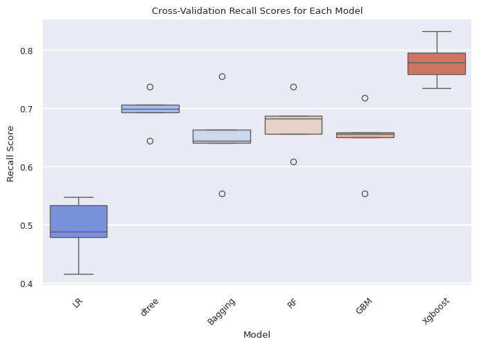

|  | Model | CV_Mean_Score |
| --- | --- | --- |
| 0 | LR | 0.49276 |
| 1 | dtree | 0.69585 |
| 2 | Bagging | 0.65133 |
| 3 | RF | 0.67419 |
| 4 | GBM | 0.64774 |
| 5 | Xgboost | 0.77999 |

```python
# Display boxplot for Cross-validation results for each model
plot_cv_results(cv_results_org)

# Display Cross-validation mean scores all models using training data
cv_means_org
```

**Observations:**

#### Compare Traing vs Validation Recall Score for Original data

```python
# Create Training Recall Scores for each models
train_scores_org = create_recall_scores(models_org, X_train, y_train, X_train, y_train, 'Recall_Train_Org')

# Create Validation Recall Scores for each models
val_scores_org = create_recall_scores(models_org, X_train, y_train, X_val, y_val, 'Recall_Val_Org')

# Merget Train and Validation Recall scores for easy comparison
recall_scores_org = pd.merge(train_scores_org, val_scores_org, on='Model')
recall_scores_org
```

|  | Model | Recall_Train_Org | Recall_Val_Org |
| --- | --- | --- | --- |
| 0 | LR | 0.49519 | 0.48201 |
| 1 | dtree | 1.00000 | 0.67266 |
| 2 | Bagging | 0.96034 | 0.67986 |
| 3 | RF | 1.00000 | 0.70144 |
| 4 | GBM | 0.78245 | 0.69784 |
| 5 | Xgboost | 1.00000 | 0.78417 |

**Observations:**

### Model Building with Oversampled data

- Use SMOTE to oversample the minority class
- Build models using oversampled data
- Evaluate Cross-validation Recall score across all models
- Evaluate Training vs Validation Recall scores

#### Use SMOTE to oversample the minority class

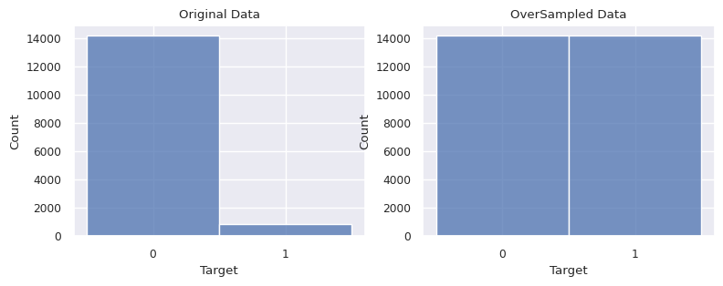

```python
# Synthetic Minority Over Sampling Technique
sm = SMOTE(sampling_strategy=1, k_neighbors=5, random_state=1)
X_train_over, y_train_over = sm.fit_resample(X_train, y_train)

# Display Target Class Distribution Before and After Oversampling
plt.figure(figsize=(14, 3))

plt.subplot(1, 3, 1)
ax=sns.histplot(y_train.apply(str));
plt.title('Original Data');

plt.subplot(1, 3, 2)
ax=sns.histplot(y_train_over.apply(str));
plt.title('OverSampled Data');
```

**Observations:**

- Target class is oversampled using Synthetic Minority Oversampling Technique (**SMOTE**).

#### Build models using oversampled data

```python
# Create models and cross-validation scores for Oversampled Data
models_over, cv_results_over, cv_means_over = build_models_and_cross_validate(X_train_over, y_train_over)
```

#### Evaluate Cross-validation Recall score across all models

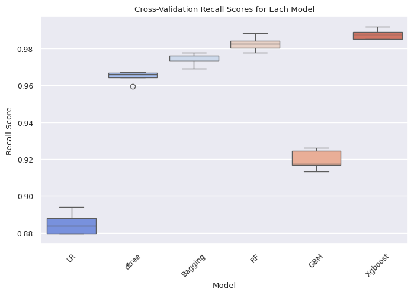

|  | Model | CV_Mean_Score |
| --- | --- | --- |
| 0 | LR | 0.88502 |
| 1 | dtree | 0.96471 |
| 2 | Bagging | 0.97381 |
| 3 | RF | 0.98264 |
| 4 | GBM | 0.91961 |
| 5 | Xgboost | 0.98772 |

```python
# Display boxplot for Cross-validation results for each model
plot_cv_results(cv_results_over)

# Display Cross-validation mean scores all models using training data
cv_means_over
```

**Observations:**

- **SMOTE** significantly improves recall scores for all models.
- **XGBoost**, **Random Forest**, and **Bagging** show exceptional performance with recall scores above 0.97.
- **Decision Tree** demonstrates notable improvement in recall scores.
- **Gradient Boosting** and **Logistic Regression** exhibit moderate recall scores, indicating lower efficacy compared to other models in the oversampled dataset.

#### Compare Traing vs Validation Recall Score for Oversampled data

```python
# Create Training Recall Scores for each models
train_scores_over = create_recall_scores(models_over, X_train_over, y_train_over, X_train_over, y_train_over, 'Recall_Train_Over')

# Create Validation Recall Scores for each models
val_scores_over = create_recall_scores(models_over, X_train_over, y_train_over, X_val, y_val, 'Recall_Val_Over')

# Merget Train and Validation Recall scores for easy comparison
recall_scores_over = pd.merge(train_scores_over, val_scores_over, on='Model')
recall_scores_over
```

|  | Model | Recall_Train_Over | Recall_Val_Over |
| --- | --- | --- | --- |
| 0 | LR | 0.88523 | 0.84892 |
| 1 | dtree | 1.00000 | 0.75899 |
| 2 | Bagging | 0.99866 | 0.79137 |
| 3 | RF | 1.00000 | 0.83453 |
| 4 | GBM | 0.92292 | 0.87410 |
| 5 | Xgboost | 0.99929 | 0.85971 |

**Observations:**

### Model Building with Undersampled data

- Use RandomUnderSampler to undersample the majority class
- Build models using undersampled data
- Evaluate Cross-validation Recall score across all models
- Evaluate Training vs Validation Recall scores

#### RandomUnderSampler to undersample the majority class

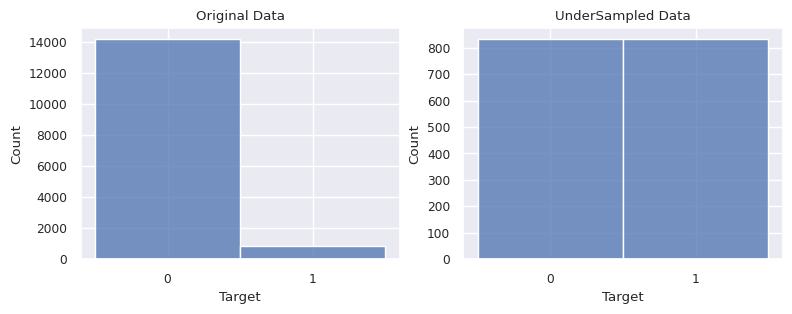

```python
# Random undersampler for under sampling the data
rus = RandomUnderSampler(random_state=1, sampling_strategy=1)
X_train_un, y_train_un = rus.fit_resample(X_train, y_train)

# Display Target Class Distribution Before and After Oversampling
plt.figure(figsize=(14, 3))

plt.subplot(1, 3, 1)
ax=sns.histplot(y_train.apply(str));
plt.title('Original Data');

plt.subplot(1, 3, 2)
ax=sns.histplot(y_train_un.apply(str));
plt.title('UnderSampled Data');
```

- Target class is undersampled using **RandomUnderSampler**.

#### Build models using undersampled data

```python
# Create models and cross-validation scores for Undersampled Data
models_un, cv_results_un, cv_means_un = build_models_and_cross_validate(X_train_un, y_train_un)
```

#### Evaluate Cross-validation Recall score across all models

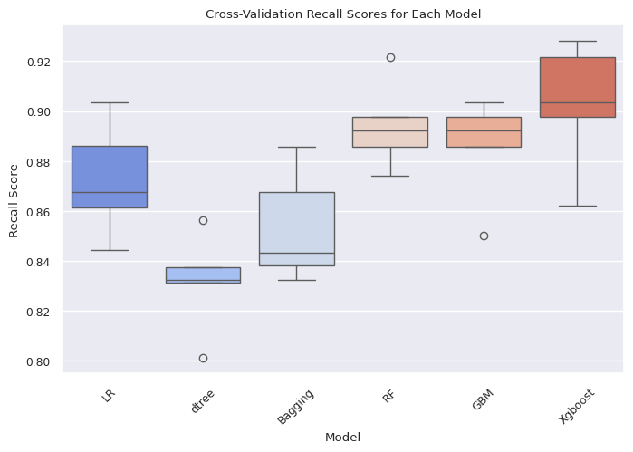

|  | Model | CV_Mean_Score |
| --- | --- | --- |
| 0 | LR | 0.87261 |
| 1 | dtree | 0.83170 |
| 2 | Bagging | 0.85341 |
| 3 | RF | 0.89426 |
| 4 | GBM | 0.88585 |
| 5 | Xgboost | 0.90266 |

```python
# Display boxplot for Cross-validation results for each model
plot_cv_results(cv_results_un)

# Display Cross-validation mean scores all models using training data
cv_means_un
```

**Observations:**

#### Compare Traing vs Validation Recall Score for Undersampled data

```python
# Create Training Recall Scores for each models
train_scores_un = create_recall_scores(models_un, X_train_un, y_train_un, X_train_un, y_train_un, 'Recall_Train_Un')

# Create Validation Recall Scores for each models
val_scores_un = create_recall_scores(models_un, X_train_un, y_train_un, X_val, y_val, 'Recall_Val_Un')

# Merget Train and Validation Recall scores for easy comparison
recall_scores_un = pd.merge(train_scores_un, val_scores_un, on='Model')
recall_scores_un
```

|  | Model | Recall_Train_Un | Recall_Val_Un |
| --- | --- | --- | --- |
| 0 | LR | 0.87500 | 0.85252 |
| 1 | dtree | 1.00000 | 0.83453 |
| 2 | Bagging | 0.98077 | 0.86331 |
| 3 | RF | 1.00000 | 0.88489 |
| 4 | GBM | 0.93269 | 0.88489 |
| 5 | Xgboost | 1.00000 | 0.88129 |

**Observations:**

### Model Selection for Hyperparameter Tuning

- Compare Mean Cross-validation Recall Scores
- Compare Training vs Validation Recall Scores
- Observations and Model Selection for Hyperparameter Tuning

#### Compare Mean Cross-validation Recall Scores across all models

```python
# Merge CV-Results Mean Recall scores for each models for easy evaluation
df_cvmeans = pd.merge(cv_means_org, cv_means_over, on='Model',suffixes=('_org','_over'))
df_cvmeans = pd.merge(df_cvmeans, cv_means_un, on='Model')
df_cvmeans.rename(columns={'CV_Mean_Score': 'CV_Mean_Score_un'}, inplace=True)
df_cvmeans
```

|  | Model | CV_Mean_Score_org | CV_Mean_Score_over | CV_Mean_Score_un |
| --- | --- | --- | --- | --- |
| 0 | LR | 0.49276 | 0.88502 | 0.87261 |
| 1 | dtree | 0.69585 | 0.96471 | 0.83170 |
| 2 | Bagging | 0.65133 | 0.97381 | 0.85341 |
| 3 | RF | 0.67419 | 0.98264 | 0.89426 |
| 4 | GBM | 0.64774 | 0.91961 | 0.88585 |
| 5 | Xgboost | 0.77999 | 0.98772 | 0.90266 |

#### Compare Training vs Validation Recall Scores across all models

```python
# Merge the dataframes on the 'Model' column
df_combined = pd.merge(recall_scores_org, recall_scores_over, on='Model')
df_combined = pd.merge(df_combined, recall_scores_un, on='Model')

# Display the combined dataframe
df_combined
```

|  | Model | Recall_Train_Org | Recall_Val_Org | Recall_Train_Over | Recall_Val_Over | Recall_Train_Un | Recall_Val_Un |
| --- | --- | --- | --- | --- | --- | --- | --- |
| 0 | LR | 0.49519 | 0.48201 | 0.88523 | 0.84892 | 0.87500 | 0.85252 |
| 1 | dtree | 1.00000 | 0.67266 | 1.00000 | 0.75899 | 1.00000 | 0.83453 |
| 2 | Bagging | 0.96034 | 0.67986 | 0.99866 | 0.79137 | 0.98077 | 0.86331 |
| 3 | RF | 1.00000 | 0.70144 | 1.00000 | 0.83453 | 1.00000 | 0.88489 |
| 4 | GBM | 0.78245 | 0.69784 | 0.92292 | 0.87410 | 0.93269 | 0.88489 |
| 5 | Xgboost | 1.00000 | 0.78417 | 0.99929 | 0.85971 | 1.00000 | 0.88129 |

#### Observations and Model Selection for Hyperparameter Tuning:

**Observations:**

**1. Gradient Boost Model:**

- Shows good generalization with high recall scores on both training and validation datasets prepared using various sampling techniques.

**2. Logistic Regression Model:**

- Although the model doesn't perform well on Original Data, it exhibits consistent performance across training and validation datasets with minimal overfitting on oversampled and undersampled data.

**3. Bagging Classifier:**

- Shows moderate overfitting, we will try to tune this model further and analyze the performance.

## Model Building with Hyperparameter Tuning

- Gradient Boost - Model Tuning
- Logistic Regression - Model Tuning
- Bagging Classifier - Model Tuning

### Gradient Boosting Tuning

- Define Model and Setting Paramters
- Model Tuning using RandomizedSearchCV on Original, Oversampled and Undersampled Data
- Evaluate Model Performance Scores

#### Define Model and Setting Paramters

```python
# Define Logistic Regression model
gbm = GradientBoostingClassifier(random_state=1)

# Setting parameters based on the recommendations
param_grid_gbm = { "n_estimators": np.arange(100,150,25), "learning_rate": [0.2, 0.05, 1], "subsample":[0.5,0.7], "max_features":[0.5,0.7] }
```

#### Model Tuning using RandomizedSearchCV

```python
# Tune model using RandomizedSearchCV by calling 'tune_model()' function. Get best parameters and score for original, oversampled and undersampled data.
best_params_gbm_org, best_score_gbm_org = tune_model(gbm, X_train, y_train, param_grid_gbm, scorer)
best_params_gbm_over, best_score_gbm_over = tune_model(gbm, X_train_over, y_train_over, param_grid_gbm, scorer)
best_params_gbm_un, best_score_gbm_un = tune_model(gbm, X_train_un, y_train_un, param_grid_gbm, scorer)

# Display Best Parameters and Score
print('Gradient Boost:\n')
print(f'Original Data - Best parameters: {best_params_gbm_org},\n Best CV Score: {best_score_gbm_org}\n')
print(f'\nOversampled Data - Best parameters: {best_params_gbm_over},\n Best CV Score: {best_score_gbm_over}\n')
print(f'\nUndersampled Data - Best parameters: {best_params_gbm_un},\n Best CV Score: {best_score_gbm_un}')
```

```
Gradient Boost:

Original Data - Best parameters: {'subsample': 0.7, 'n_estimators': 125, 'max_features': 0.5, 'learning_rate': 0.2},
 Best CV Score: 0.7068537623548086


Oversampled Data - Best parameters: {'subsample': 0.7, 'n_estimators': 125, 'max_features': 0.5, 'learning_rate': 1},
 Best CV Score: 0.9613909162628872


Undersampled Data - Best parameters: {'subsample': 0.5, 'n_estimators': 125, 'max_features': 0.5, 'learning_rate': 0.05},
 Best CV Score: 0.8894163480268379
```

#### Evaluate Model Performance

```python
# Evaluate performance on tuned model trained on Original, Oversampled and Undersamped data
tuned_gbm_recall_org = evaluate_tuned_model('GBM_Tuned', GradientBoostingClassifier, X_train, y_train, X_val, y_val, best_params_gbm_org, 'Org')
tuned_gbm_recall_over = evaluate_tuned_model('GBM_Tuned', GradientBoostingClassifier, X_train_over, y_train_over, X_val, y_val, best_params_gbm_over, 'Over')
tuned_gbm_recall_un = evaluate_tuned_model('GBM_Tuned', GradientBoostingClassifier, X_train_un, y_train_un, X_val, y_val, best_params_gbm_un, 'Un')

# Combine recall scores to have a consolidated view
tuned_gbm_recall_combined = pd.merge(tuned_gbm_recall_org, tuned_gbm_recall_over, on='Model')
tuned_gbm_recall_combined = pd.merge(tuned_gbm_recall_combined, tuned_gbm_recall_un, on='Model')

print('Recall Score - Gradient Boosting:\n')
tuned_gbm_recall_combined
```

```
Recall Score - Gradient Boosting:
```

|  | Model | Recall_Train_Org | Recall_Val_Org | Recall_Train_Over | Recall_Val_Over | Recall_Train_Un | Recall_Val_Un |
| --- | --- | --- | --- | --- | --- | --- | --- |
| 0 | GBM_Tuned | 0.82452 | 0.73741 | 0.98511 | 0.83813 | 0.90745 | 0.88129 |

**Observations:**

- Tuned Gradient Boosting model show good Recall score for model trained on Undersampled data.
- Model shows moderate overfitting when trained using Original and Oversampled data.
- We will continue to evaluate performance on Tuned Logistic Regression and Bagging Classifier models, before concluding.

### Logistic Regression Tuning

- Define Model and Setting Paramters
- Model Tuning using RandomizedSearchCV on Original, Oversampled and Undersampled Data
- Evaluate Model Performance Scores

#### Define Model and Setting Parameters

```python
# Define Logistic Regression model
lr = LogisticRegression(random_state=1)

# Setting parameters based on the recommendations
param_grid_lr = {'C': np.arange(0.1,1.1,0.1)}
```

#### Model Tuning using RandomizedSearchCV

```python
# Tune model using RandomizedSearchCV by calling 'tune_model()' function. Get best parameters and score for original, oversampled and undersampled data.
best_params_lr_org, best_score_lr_org = tune_model(lr, X_train, y_train, param_grid_lr, scorer)
best_params_lr_over, best_score_lr_over = tune_model(lr, X_train_over, y_train_over, param_grid_lr, scorer)
best_params_lr_un, best_score_lr_un = tune_model(lr, X_train_un, y_train_un, param_grid_lr, scorer)

# Display Best Parameters and Score
print('Logistic Regression:\n')
print(f'Original Data - Best parameters: {best_params_lr_org},\n Best CV Score: {best_score_lr_org}\n')
print(f'\nOversampled Data - Best parameters: {best_params_lr_over},\n Best CV Score: {best_score_lr_over}\n')
print(f'\nUndersampled Data - Best parameters: {best_params_lr_un},\n Best CV Score: {best_score_lr_un}')
```

```
Logistic Regression:

Original Data - Best parameters: {'C': 0.2},
 Best CV Score: 0.4952240098117019


Oversampled Data - Best parameters: {'C': 0.1},
 Best CV Score: 0.8850932688913629


Undersampled Data - Best parameters: {'C': 0.1},
 Best CV Score: 0.8665608541952239
```

#### Evaluate Model Performance

```python
# Evaluate performance on tuned model trained on Original, Oversampled and Undersamped data
tuned_lr_recall_org = evaluate_tuned_model('LR_Tuned', LogisticRegression, X_train, y_train, X_val, y_val, best_params_lr_org, 'Org')
tuned_lr_recall_over = evaluate_tuned_model('LR_Tuned', LogisticRegression, X_train_over, y_train_over, X_val, y_val, best_params_lr_over, 'Over')
tuned_lr_recall_un = evaluate_tuned_model('LR_Tuned', LogisticRegression, X_train_un, y_train_un, X_val, y_val, best_params_lr_un, 'Un')

# Combine recall scores to have a consolidated view
tuned_lr_recall_combined = pd.merge(tuned_lr_recall_org, tuned_lr_recall_over, on='Model')
tuned_lr_recall_combined = pd.merge(tuned_lr_recall_combined, tuned_lr_recall_un, on='Model')

print('Recall Score - Logistic Regression:\n')
tuned_lr_recall_combined
```

```
Recall Score - Logistic Regression:
```

|  | Model | Recall_Train_Org | Recall_Val_Org | Recall_Train_Over | Recall_Val_Over | Recall_Train_Un | Recall_Val_Un |
| --- | --- | --- | --- | --- | --- | --- | --- |
| 0 | LR_Tuned | 0.49519 | 0.48201 | 0.88523 | 0.84892 | 0.87500 | 0.85252 |

**Observations:**

### Bagging Classifier Tuning

- Define Model and Setting Paramters
- Model Tuning using RandomizedSearchCV on Original, Oversampled and Undersampled Data
- Evaluate Model Performance Scores

#### Define Model and Setting Paramters

```python
# Define Bagging Classifier model
bclf = BaggingClassifier(random_state=1)

# Setting parameters based on the recommendations
param_grid_bclf = { 'max_samples': [0.7,0.8,0.9], 'max_features': [0.7,0.8,0.9], 'n_estimators' : [50,70,90], }
```

#### Model Tuning using RandomizedSearchCV

```python
# Tune model using RandomizedSearchCV by calling 'tune_model()' function. Get best parameters and score for original, oversampled and undersampled data.
best_params_bclf_org, best_score_bclf_org = tune_model(bclf, X_train, y_train, param_grid_bclf, scorer)
best_params_bclf_over, best_score_bclf_over = tune_model(bclf, X_train_over, y_train_over, param_grid_bclf, scorer)
best_params_bclf_un, best_score_bclf_un = tune_model(bclf, X_train_un, y_train_un, param_grid_bclf, scorer)

# Display Best Parameters and Score
print('Bagging Classifer:\n')
print(f'Original Data - Best parameters: {best_params_bclf_org},\n Best CV Score: {best_score_bclf_org}\n')
print(f'\nOversampled Data - Best parameters: {best_params_bclf_over},\n Best CV Score: {best_score_bclf_over}\n')
print(f'\nUndersampled Data - Best parameters: {best_params_bclf_un},\n Best CV Score: {best_score_bclf_un}')
```

```
Bagging Classifer:

Original Data - Best parameters: {'n_estimators': 90, 'max_samples': 0.9, 'max_features': 0.8},
 Best CV Score: 0.6864367650241685


Oversampled Data - Best parameters: {'n_estimators': 90, 'max_samples': 0.9, 'max_features': 0.8},
 Best CV Score: 0.9813665487483562


Undersampled Data - Best parameters: {'n_estimators': 50, 'max_samples': 0.8, 'max_features': 0.7},
 Best CV Score: 0.8869850660125532
```

#### Evaluate Model Performance

```python
# Evaluate performance on tuned model trained on Original, Oversampled and Undersamped data
tuned_bclf_recall_org = evaluate_tuned_model('Bagging_Tuned', BaggingClassifier, X_train, y_train, X_val, y_val, best_params_bclf_org, 'Org')
tuned_bclf_recall_over = evaluate_tuned_model('Bagging_Tuned', BaggingClassifier, X_train_over, y_train_over, X_val, y_val, best_params_bclf_over, 'Over')
tuned_bclf_recall_un = evaluate_tuned_model('Bagging_Tuned', BaggingClassifier, X_train_un, y_train_un, X_val, y_val, best_params_bclf_un, 'Un')

# Combine recall scores to have a consolidated view
tuned_bclf_recall_combined = pd.merge(tuned_bclf_recall_org, tuned_bclf_recall_over, on='Model')
tuned_bclf_recall_combined = pd.merge(tuned_bclf_recall_combined, tuned_bclf_recall_un, on='Model')

print('Recall Score - Bagging Classifer:\n')
tuned_bclf_recall_combined
```

```
Recall Score - Bagging Classifer:
```

|  | Model | Recall_Train_Org | Recall_Val_Org | Recall_Train_Over | Recall_Val_Over | Recall_Train_Un | Recall_Val_Un |
| --- | --- | --- | --- | --- | --- | --- | --- |
| 0 | Bagging_Tuned | 0.99399 | 0.69784 | 1.00000 | 0.84173 | 0.98678 | 0.88849 |

**Observations:**

- Tuned Baggiging Classifier shows moderate overfitting on model trained using Oversampled and Undersampled data.

## Model performance comparison and choosing Final model

- Model Performance Comparison
- Final Model Selection
- Test data performance evaluation
- Feature Importance

### Model Performance Comparison

```python
# Build dataframe showing recall score performance all models
recall_score_comparison = pd.concat([df_combined, tuned_gbm_recall_combined, tuned_lr_recall_combined, tuned_bclf_recall_combined])

# Set the 'Model' column as the index
recall_score_comparison.set_index('Model', inplace=True)

# Display combined model performance
recall_score_comparison.T
```

| Model | LR | dtree | Bagging | RF | GBM | Xgboost | GBM_Tuned | LR_Tuned | Bagging_Tuned |
| --- | --- | --- | --- | --- | --- | --- | --- | --- | --- |
| Recall_Train_Org | 0.49519 | 1.00000 | 0.96034 | 1.00000 | 0.78245 | 1.00000 | 0.82452 | 0.49519 | 0.99399 |
| Recall_Val_Org | 0.48201 | 0.67266 | 0.67986 | 0.70144 | 0.69784 | 0.78417 | 0.73741 | 0.48201 | 0.69784 |
| Recall_Train_Over | 0.88523 | 1.00000 | 0.99866 | 1.00000 | 0.92292 | 0.99929 | 0.98511 | 0.88523 | 1.00000 |
| Recall_Val_Over | 0.84892 | 0.75899 | 0.79137 | 0.83453 | 0.87410 | 0.85971 | 0.83813 | 0.84892 | 0.84173 |
| Recall_Train_Un | 0.87500 | 1.00000 | 0.98077 | 1.00000 | 0.93269 | 1.00000 | 0.90745 | 0.87500 | 0.98678 |
| Recall_Val_Un | 0.85252 | 0.83453 | 0.86331 | 0.88489 | 0.88489 | 0.88129 | 0.88129 | 0.85252 | 0.88849 |

**Observations**

### Test set performance review using Tuned Gradient Boosting Machine trained on Undersampled data

```python
# Evaluate performance on Test Data using Tuned Gradient Boosting Machine trained on Undersampled Data
gbm_tuned_un = GradientBoostingClassifier(**best_params_gbm_un,random_state=1)
gbm_tuned_un = gbm_tuned_un.fit(X_train_un, y_train_un)

# Get performance scores for Training, Validation and Test sets
gbm_perf_train = model_performance_classification_sklearn(gbm_tuned_un,X_train_un, y_train_un)
gbm_perf_val = model_performance_classification_sklearn(gbm_tuned_un,X_val, y_val)
gbm_perf_test = model_performance_classification_sklearn(gbm_tuned_un,X_test, y_test)

# Set index names for each DataFrame
gbm_perf_train.index = ['Train']
gbm_perf_val.index = ['Validation']
gbm_perf_test.index = ['Test']

# Display Tuned Gradient Boosting Machine model - Undersampled Data performance on Test Data
gbm_perf_combined = pd.concat([gbm_perf_train, gbm_perf_val, gbm_perf_test])
gbm_perf_combined
```

|  | Accuracy | Recall | Precision | F1 |
| --- | --- | --- | --- | --- |
| Train | 0.93810 | 0.90745 | 0.96671 | 0.93614 |
| Validation | 0.91660 | 0.88129 | 0.38951 | 0.54024 |
| Test | 0.91800 | 0.87234 | 0.39677 | 0.54545 |

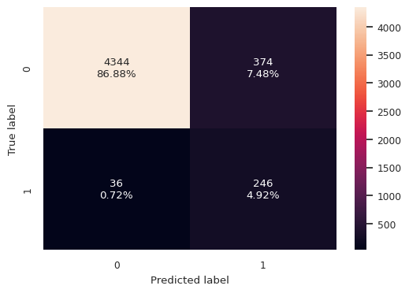

```python
# Display Confusion Matrix
confusion_matrix_plot(gbm_tuned_un, X_test, y_test)
```

**Observations:**

- Model shows strong Accuracy and Reall performance on Test set.
- This model is also free from overfitting.
- Confusion matrix also shows low False Negatives of 0.72%, which meets our model requirements, avoiding replacement cost.
- We will use Tuned Gradient Boosting Machine model trained on Undersampled data for production using pipeline.
- Let's review its important features.

### Feature of Importance

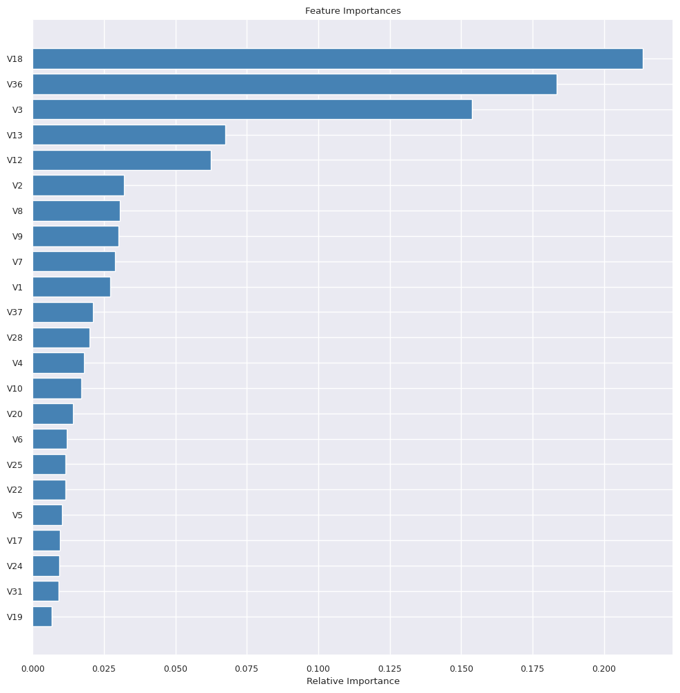

```python
feature_names = X_train_un.columns
importances =  gbm_tuned_un.feature_importances_ ## Complete the code to check the feature importance of the best model
indices = np.argsort(importances)

plt.figure(figsize=(12, 12))
plt.title("Feature Importances")
plt.barh(range(len(indices)), importances[indices], color="steelblue", align="center")
plt.yticks(range(len(indices)), [feature_names[i] for i in indices])
plt.xlabel("Relative Importance")
plt.show()
```

**Observations:**

- V18, V36 and V3 are the top 3 predictors influencing the target variable.
- V13 and V12 show moderate importance and
- There are other 18 features with some importance on predicting Target variable.

## Pipeline to build the final model

- Define pipeline
- Predict Target Variable

### Define Pipeline

```python
# Assuming best_params is a dictionary with the best hyperparameters
finalmodel_best_params = best_params_gbm_un

# Creating a new pipeline with best parameters
finalmodel_pipeline = Pipeline(
    steps=[
        ("imputer", KNNImputer(n_neighbors=5)), # Impute missing values using KNNImputer
        ("undersampler", RandomUnderSampler(random_state=1)), # Use RandomUnderSampler for Under sampling the data
        ("gbm_tuned_un", GradientBoostingClassifier(
            **finalmodel_best_params,
            random_state=1,
        )), # Build Gradient Boosting Machine model using best parameters returned by RandomizedSearchCV
    ]
)

# Fit the model on training data
finalmodel_pipeline.fit(X_train, y_train)
```

```
Pipeline(steps=[('imputer', KNNImputer()),
                ('undersampler', RandomUnderSampler(random_state=1)),
                ('gbm_tuned_un',
                 GradientBoostingClassifier(learning_rate=0.05,
                                            max_features=0.5, n_estimators=125,
                                            random_state=1, subsample=0.5))])
```

### Predict the target variable

```python
# Predict Target variable for test dataset
y_predict= finalmodel_pipeline.predict(X_test);

# Compare predictions with test variables
pred_test = pd.DataFrame({"Actual": y_test, "Predicted": y_predict})
pred_test.head(10)
```

|  | Actual | Predicted |
| --- | --- | --- |
| 0 | 0 | 0 |
| 1 | 0 | 0 |
| 2 | 0 | 0 |
| 3 | 0 | 0 |
| 4 | 0 | 1 |
| 5 | 0 | 0 |
| 6 | 0 | 0 |
| 7 | 0 | 0 |
| 8 | 0 | 0 |
| 9 | 0 | 0 |

## Business Insights and Conclusions

Renewable energy sources, notably wind energy, are crucial to our sustainable energy future. The ability to predict and prevent failures in wind turbine generators can significantly reduce operational and maintenance costs. Our analytical approach and machine learning models have identified key insights:

**Important Features:**

- **Top Predictive Features:** Analysis reveals that **V18**, **V36**, and **V3** are the most significant features influencing generator failure predictions. Close attention to these sensors could preempt costly downtimes.
- **Secondary Predictive Features:** Features **V13** and **V12** also demonstrate moderate importance, suggesting that while they have a lesser impact, they still contribute valuable predictive power to the model.

**Model Performance:**

- **The Gradient Boosting Machine model tuned with undersampled data** (gbm_tuned_un) emerged as the optimal model without overfitting, achieving an 91% recall on training data, an 88% recall on validation data, and an impressive 87% recall on unseen test data.
- The model's robustness is further supported by 92% accuracy in identifying true negatives, essential for minimizing false alarm rates.

**Other Important Insights:**

- **Cost-Effective Maintenance:** By accurately identifying true positive failure cases (TP), the model ensures repair efforts are timely and cost-effective, while minimizing the incidence of false negatives (FN) that could result in expensive generator replacements.
- **Maintenance Policy Recommendations:** The insights gained from the model's feature importance can refine maintenance checks, focusing on high-impact factors and adjusting sensor data collection frequency to improve predictive accuracy.
- **Pipeline Deployment:** The deployment of a machine learning pipeline incorporating the chosen GBM model will allow for real-time predictive analysis, further reducing maintenance response times and costs.
- **Future Enhancements:** Continuous improvement of the machine learning model through the integration of additional data and advanced analytics will drive further cost savings and operational efficiency.

In conclusion, the predictive maintenance model not only fulfills the objective of reducing maintenance costs but also aligns with the broader goal of sustainable energy production by enhancing the reliability and efficiency of wind turbines. The company, ReneWind, is now equipped to implement a more proactive maintenance strategy, ensuring operational resilience and cost savings.

### Other explanations:

- **KNNImputer Usage:** Chosen for its ability to impute missing values by leveraging the underlying patterns in the data, KNNImputer uses the nearest neighbors approach, providing a nuanced estimation that simple mean or median replacement methods can't match.
- **imblearn.pipeline Usage:** Utilized for its compatibility with resampling techniques, the imblearn.pipeline ensures that class balancing via methods like RandomUnderSampler is appropriately applied during the training process to prevent data leakage and maintain the integrity of cross-validation.